# IODS course project

**g. Interpretation of biplot of standardized datatset:**

- The biplot shows the first two principal component scores. Maternal mortality rate and adolescent birth rate seems to be closely related and pointing towards the least development countries, for instance, Sierra Leone. Similarly, percetange of female representatives in parliament and ratio of female-male shares in labor force participation appears to be closely related and pointing towards countries like Tanzania. Expected years of schooling, Life expectancy at birth, ratio of female-male shares in secondary education appears to be closely related and pointing towards developed countries.

**h. Caption (replacing PC1 and PC2) of the standardized plot**

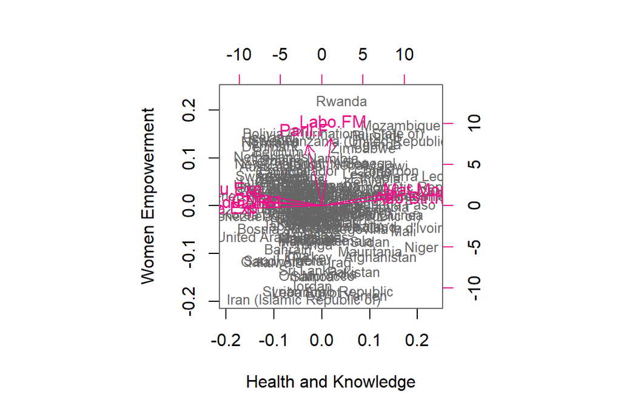

**i. Cos2 : quality of the representation for variables on the factor map**

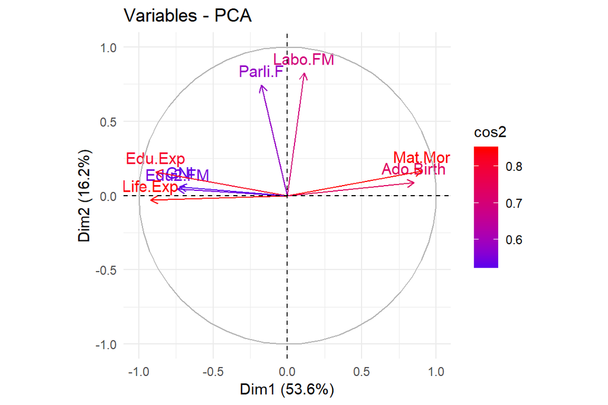

- Showing the most contributing indicators in explaining the variations retained by the principal components.

### **4. Personal interpretations of the first two principal component dimensions based on the biplot**

**a. Selecting the top 3 contributing variables**

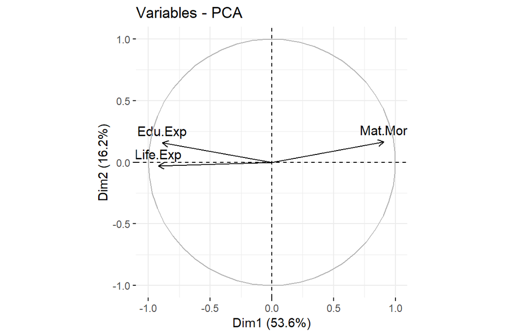

**b. Contributions of variables on PC1**

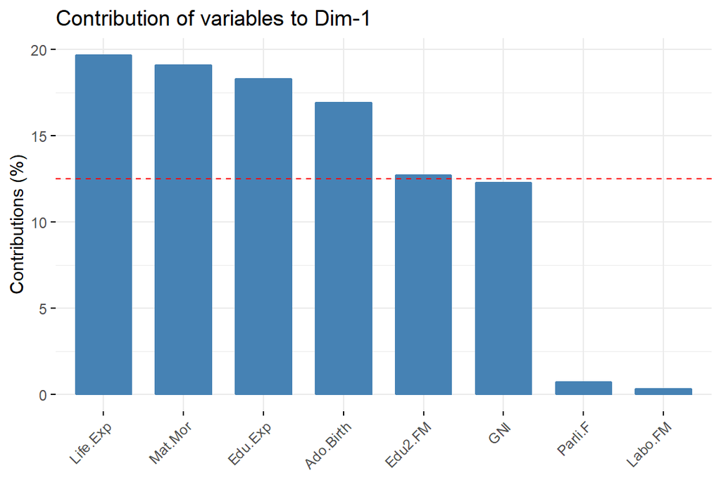

**c. Contributions of variables on PC2**

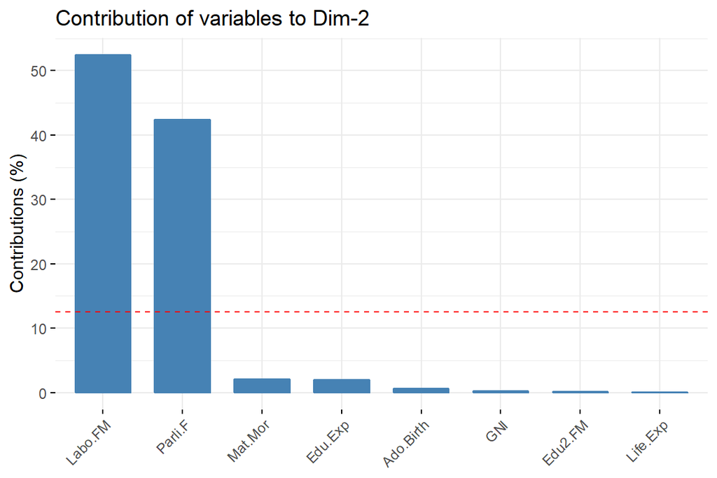

**d. Interpretation of the above mentioned plots**

- The variables that are correlated with Dim1 and Dim2 are the most relevant in explaining the variability.
- The most important contributing variables in the data set are Maternal mortality ratio, Life expectancy at birth and Expected years of schooling as shown above.
- The red line on the plots above shows the expected average contribution. The variables present in the dataset larger than this cutoff can be considered important in contributing to the principal component.
- The first principal component corresponds to a measure of Life expectancy at birth and Maternal mortality rate. Similarly, it can be said that the second component corresponds to a measure of percetange of female representatives in parliament and labour force participation rate, female-male ratio.

### **5. Tea dataset**

```
## 'data.frame':    300 obs. of  36 variables:
##  $ breakfast       : Factor w/ 2 levels "breakfast","Not.breakfast": 1 1 2 2 1 2 1 2 1 1 ...
##  $ tea.time        : Factor w/ 2 levels "Not.tea time",..: 1 1 2 1 1 1 2 2 2 1 ...
##  $ evening         : Factor w/ 2 levels "evening","Not.evening": 2 2 1 2 1 2 2 1 2 1 ...
##  $ lunch           : Factor w/ 2 levels "lunch","Not.lunch": 2 2 2 2 2 2 2 2 2 2 ...
##  $ dinner          : Factor w/ 2 levels "dinner","Not.dinner": 2 2 1 1 2 1 2 2 2 2 ...
##  $ always          : Factor w/ 2 levels "always","Not.always": 2 2 2 2 1 2 2 2 2 2 ...
##  $ home            : Factor w/ 2 levels "home","Not.home": 1 1 1 1 1 1 1 1 1 1 ...
##  $ work            : Factor w/ 2 levels "Not.work","work": 1 1 2 1 1 1 1 1 1 1 ...
##  $ tearoom         : Factor w/ 2 levels "Not.tearoom",..: 1 1 1 1 1 1 1 1 1 2 ...
##  $ friends         : Factor w/ 2 levels "friends","Not.friends": 2 2 1 2 2 2 1 2 2 2 ...
##  $ resto           : Factor w/ 2 levels "Not.resto","resto": 1 1 2 1 1 1 1 1 1 1 ...
##  $ pub             : Factor w/ 2 levels "Not.pub","pub": 1 1 1 1 1 1 1 1 1 1 ...
##  $ Tea             : Factor w/ 3 levels "black","Earl Grey",..: 1 1 2 2 2 2 2 1 2 1 ...
##  $ How             : Factor w/ 4 levels "alone","lemon",..: 1 3 1 1 1 1 1 3 3 1 ...
```

[output cut: 22 more lines]

```
## [1] 300  36
```

**a. Structure and the dimensions of the data**

- The tea dataset has been loaded from the package Factominer. The original dataset has 300 obs. of 36 variables. The variables included in the dataset are breakfast, teatime, always, home, work, price, diuretic etc.
- 300 individuals who participated in the survey were asked about how they drink tea (18 questions), what are their product’s perception (12 questions) and some personal details (4 questions).

```
##         Tea         How             healthy         sugar
##  black    : 74   alone:195   healthy    :210   No.sugar:155
##  Earl Grey:193   lemon: 33   Not.healthy: 90   sugar   :145
##  green    : 33   milk : 63
##                  other:  9
##                   where           lunch
##  chain store         :192   lunch    : 44
##  chain store+tea shop: 78   Not.lunch:256
##  tea shop            : 30
##
```

```
## 'data.frame':    300 obs. of  6 variables:
##  $ Tea    : Factor w/ 3 levels "black","Earl Grey",..: 1 1 2 2 2 2 2 1 2 1 ...
##  $ How    : Factor w/ 4 levels "alone","lemon",..: 1 3 1 1 1 1 1 3 3 1 ...
##  $ healthy: Factor w/ 2 levels "healthy","Not.healthy": 1 1 1 1 2 1 1 1 2 1 ...
##  $ sugar  : Factor w/ 2 levels "No.sugar","sugar": 2 1 1 2 1 1 1 1 1 1 ...
##  $ where  : Factor w/ 3 levels "chain store",..: 1 1 1 1 1 1 1 1 2 2 ...
##  $ lunch  : Factor w/ 2 levels "lunch","Not.lunch": 2 2 2 2 2 2 2 2 2 2 ...
```

- For the current analysis, some of the variables from the tea dataset has been selected which are ‘tea’, ‘How’, ‘healthy’, ‘sugar’, ‘where’ and ‘lunch’. All the variables are categorical.
- It has 300 obs. of 6 variables.

**b. Visualize the dataset**

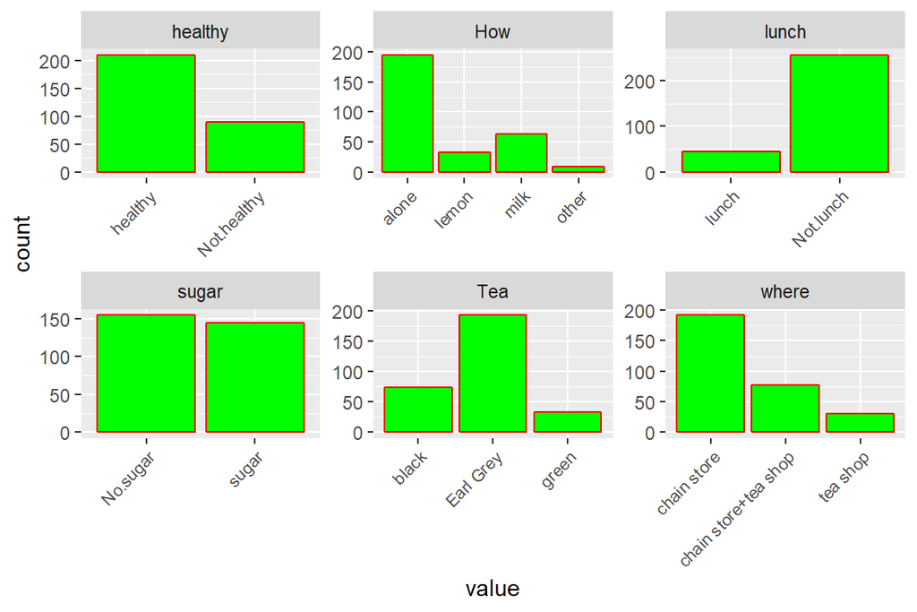

Most of the tea consumers were:

- Healthy
- Preferred Earl grey tea
- Preferred tea alone without any addition of milk, lemon and other stuff
- Preferred sipping tea other than the lunch time
- Preferred chain store.